# Informe técnico

En el presente informe se cuenta como se realizó el proceso de depuración de datos, creación de nuevas variables, manejo de fechas, obtención de los días festivos, agrupamiento de datos entre otros. También se realiza análisis descriptivo para obtener información que puede ser útil en el proceso de modelación.

# Depuración de datos

El proceso de depuración es probablemente uno de los pasos más importantes cuando se quiere hacer análisis de datos pues un modelo es tan bueno como lo sea la calidad de información que se tenga.

### Falsos únicos

Para comenzar, se resalta que todas las variables son categóricas y la mayoría de tipo carácter, el problema radica en que una gran cantidad de observaciones eran falsos únicos, por ejemplo, para la variable clase de accidente se tienen 7 posibles valores los cuales son: atropello, caida de ocupante, caída de ocupante, choque, incendio, volcamiento y otro; note que el valor caida de ocupante y caída de ocupante realmente significan lo mismo, sin embargo si son observados como cadena de caracteres son diferentes, pues uno tiene tilde y el otro no, lo cual implica que los lenguajes de programación los tomen como dos cosas diferentes. La solución a este problema fue cambiar todas las cadenas de caracteres “caída de ocupante” por “caida de ocupante” (se selecciona la cadena sin tilde para evitar posibles problemas con la codificación), esto se traduce en que finalmente dicha variable tendrá posteriormente 6 valores únicos como debería de ser.

Este problema paso en varias variables de la base de datos y el proceso para solucionar dicho inconveniente fue análogo al hecho con la variable clase de accidente.

### Variable Location

Esta variable tuvo el problema de que las coordenadas de longitud y latitud estaban invertidas. La solución fue simplemente invertir las entradas.

### Datos faltantes en variables espaciales

Los datos faltantes es un problema típico en la mayoría de las bases de datos. Para el caso particular de variables espaciales como barrio, comuna y número de comuna se utilizó la variable Location después de ser arreglada tal como se menciona en el párrafo anterior (pues esta no tuvo valores faltantes); con estas coordenadas se encontraron los datos faltantes.

### Ubicaciones fuera de Medellín

Las observaciones que estén ubicadas fuera de la ciudad son eliminadas de la base de datos, teniendo en cuenta que el interés de estudio es en Medellín. Gracias a la variable Location se encontraron datos que no estaban ubicados en la ciudad; en total se eliminaron 19733 observaciones de las cuales 19 estaban ubicadas en La estrella, 101 en Envigado y 19613 en Heliconia.

### Variable CBML

Esta variable es el catastro y no fue tenida en cuenta pues se considera que no aporta información importante para el proceso de modelación o creación de nuevas variables.

# Construcción de la base de datos para modelación

Una vez limpiada la base de datos, se construye una nueva exclusivamente para el proceso de modelación. Para la construcción de esta base de datos se parte únicamente de la variable fecha de accidente y a partir de ella se van construyendo las demás. A continuación se presenta la estructura de la base de datos resultante:

| FECHA ACCIDENTE | ACCIDENTES DIARIOS | DIA ACCIDENTE | PRECIP MES | FESTIVO | SEMANA | QUINCENA |
| --- | --- | --- | --- | --- | --- | --- |
| 2014-07-04 | 23 | vie | Seco | No | 27 | No |
| 2014-07-05 | 117 | sáb | Seco | No | 27 | No |
| 2014-07-06 | 79 | dom | Seco | No | 27 | No |
| 2014-07-07 | 164 | lun | Seco | No | 27 | No |
| 2014-07-08 | 119 | mar | Seco | No | 27 | No |
| 2014-07-09 | 118 | mié | Seco | No | 28 | No |

### Fecha accidente y accidentes diarios

Las fechas de accidentes se obtienen al tomar los diez primeros caracteres de los datos contenidos en la variable FECHA_ACCIDENTE, por ejemplo considere la cadena de caracteres 2014-08-05T12:15:00.000Z (la cual está en la base de datos depurada), la subcadena con los primeros 10 caracteres es 2014-08-05. Para el resto de observaciones se procedió de manera análoga. Posteriormente las observaciones resultantes son convertidas en objetos de la clase Date y finalmente dichas fechas fueron contadas para obtener la frecuencia de accidentes diarios. Todo esto se hace gracias a las funciones `select()`, `group_by()`, `mutate()`, `summarise()` y `n()` de la librería `dplyr` y la función `as.Date()` que viene en los paquetes básicos de R.

### Día accidente

El día del accidente es obtenido gracias a la función `wday()` de la librería `lubridate` ingresándole un objeto de la clase Date, en este caso fecha de accidente (obtenida en el párrafo anterior).

### Precipitación del mes

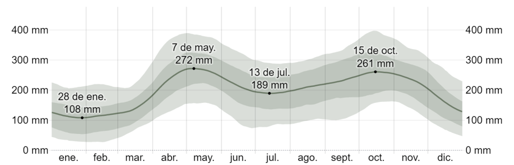

### Festivos y días especiales

Se buscó la manera de llevar la información de días festivos a la base de datos. Gracias a un repositorio de GitHub de Nequi se encontró un modulo node.js el cual a través de JavaScript se pudo exportar a un objeto JSON, luego se usó la función `fromJSON()` de la librería `rjson` para poder trabajar con JavaScript Objects Notation (JSON) en R y así extraer los datos de los días festivos en Colombia.

### Semana y Quincena

# Análisis descriptivo

En esta sección se buscan hallazgos que permitan encontrar relaciones que puedan ser utiles en la construcción de modelos

## Distribución del número de accidentes

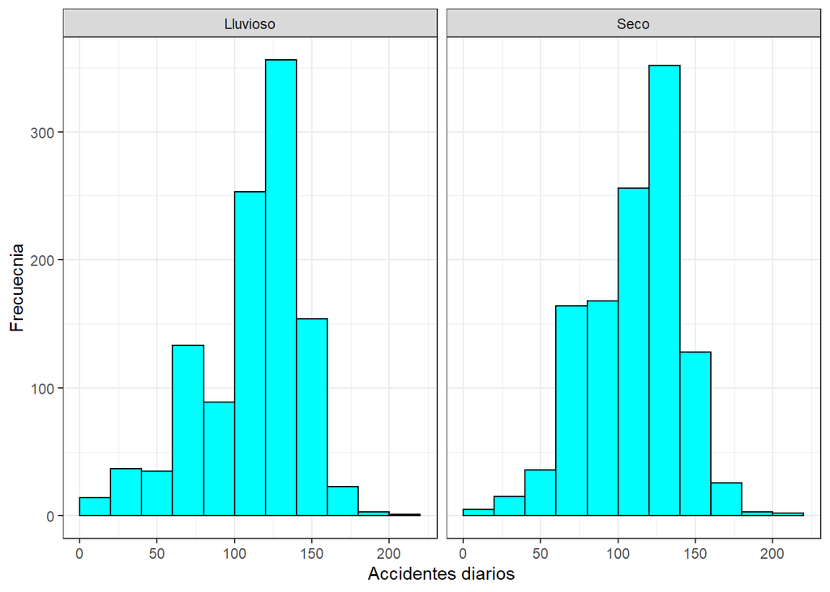

# Modelación

## Sobre Modelos

Dada la naturaleza del problema en cuestión, se meditó inicialmente utilizar un modelo de regresión lineal que considera además un proceso SARIMA, es decir, un modelo de series de tiempo que comprende un periodo estacional. Este modelo fue considerado en principio dado que se pensó inicialmente en un periodo estacional semanal, y además de esto, considerar variables regresoras exógenas como las construidas anteriormente prometía una posibilidad de buen ajuste y medidas excepcionales de desempeño. Sin embargo, después de realizar diversos ajustes y probar distintas combinaciones de variables y parámetros del modelo, las métricas de desempeño obtenidas no fueron satisfactorias y finalmente se decidió por descartar esta opción.

Posteriormente, en un breve intento se ajustó una red neuronal considerando la variable construida para el día del accidente, sin embargo, en este punto los resultados no mejoraron.

Llegado este momento, se optó por construir un modelo tradicional de regresión lineal usando múltiples subconjuntos de las variables anteriormente descritas y se llegó a un buen ajuste usando como variables el día del accidente y la variable indicadora para festivos.

Sin embargo, como es recomendado, se probaron algunas alternativas un poco más sofisticadas como el algoritmo xgboost usando respuesta poisson para conteos, o los bosques aleatorios buscando disminuir el error y lograr predicciones más precisas, sin embargo las métricas no lograron superar al modelo de regresión lineal y además, según el error relativo máximo permitido para esta causa, estos modelos se sobreajustaron considerablemente.

$$\hat{y} = \hat{\beta_0} + \hat{\beta_1} \text{(Día de accidente)} + \hat{\beta_2} \text{(Festivo)}$$

Con esto, se obtuvo un modelo con capacidad predictiva a nivel diario para el número de accidentes en la ciudad de Medellín. Para lograr predicciones a nivel semanal y mensual surgió la idea natural de sumar los días a nivel semanal y mensual, y después de evaluar métricas de desempeño en estas dimensiones, se concluyó que este procedimiento era adecuado y congruente con lo obtenido previamente y lo esperado según el error.

Por último, para predecir por categoría de accidente se optó por estimar las proporciones globales para cada una de estas, y con este nuevo “vector de proporciones según categoría” hacer la predicción en conjunto con el modelo construido para el pronóstico a nivel temporal.

## Esto puede ser una conclusión

Finalmente, en lo que respecta al proceso de modelación, se encontró que la clave para esta causa no residió en llegar a modelos muy sofisticados o algoritmos de alta complejidad. Lo fundamental en este caso fue construir y considerar las variables adecuadas que pudieran explicar desviaciones y patrones naturales en el mecanismo que representa el número de accidentes en la ciudad de Medellín.